# Emotion Ratings Analysis

Leonardo Cerliani

2024-05-13

```r
library(tidyverse)

bd <- "/data00/leonardo/RSA/analyses/RATINGS"

subs_file <- "/data00/leonardo/RSA/sub_list.txt"
subs <- sprintf("%02d",readLines(subs_file) %>% as.numeric)

# Load the preprocessed emotion ratings file
# which was prepared with the 02_prepare_ratings_EMOTION.Rmd
# located in /data00/leonardo/RSA/prep_scripts/05_prepare_ratings
df <- read_csv(paste0(bd,"/","emotion_ratings.csv"))
```

# Examine movie/rating congruence

Congruence is defined in a very simple way:

- the subject’s rating is congruent if - in each trial - the highest score is given to the emotion which is actually displayed in the movie.
- congruence is therefore here defined as a binary variable.

```r
calculate_congruence <- function(df, highlow_flag = "ALL") {

  cat("highlow_flag = ", highlow_flag, "\n")

  if (highlow_flag %in% c("high","low")) {
    df <- df %>% filter(str_detect(high_low_code, highlow_flag))
  }

  df_congruence <- df %>%
    select(sub,original_code, emotion, starts_with("r_")) %>%
    pivot_longer(starts_with("r_"), names_to = "rating") %>%
    group_by(sub, original_code, emotion) %>%
    filter(value == max(value)) %>%
    filter(value != 0) %>%
    mutate(rating = str_remove(rating,"r_")) %>%
    mutate(consistent = ifelse(emotion==rating,1,0)) %>%
    ungroup %>%
    group_by(sub) %>%  # here you could also group by emotion
    summarise(
      congruence = round(sum(consistent)/n(),2)
    )

  return(df_congruence)
}

# # OLE plot, suitable only for one of ALL, high, low at the time
# df_congruence %>%
#   ggplot(aes(x = reorder(sub, congruence), y = congruence)) +
#   geom_bar(stat = "identity", color = "grey", fill = "lightblue") +
#   theme_minimal() +
#   labs(title = "Congruence between displayed emotion and max rated emotion", x = "sub")


# calculate congruence for ALL, high, low, using the fn above
df_congruence <- calculate_congruence(df,"ALL") %>%
  rename(ALL = congruence) %>%
  inner_join(calculate_congruence(df,"high"), by="sub") %>%
  rename(high = congruence) %>%
  inner_join(calculate_congruence(df,"low"), by="sub") %>%
  rename(low = congruence)
```

```
## highlow_flag =  ALL
## highlow_flag =  high
## highlow_flag =  low
```

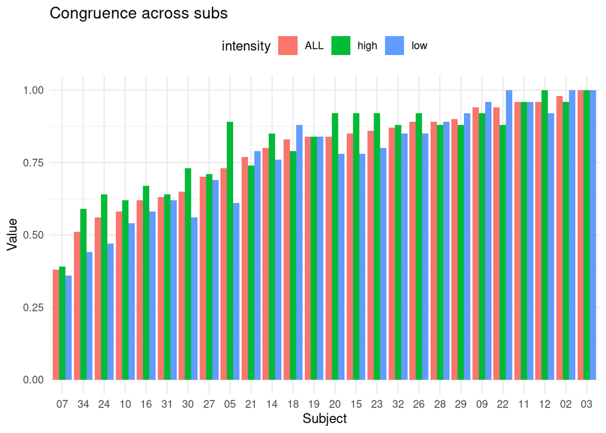

```r
df_congruence %>%
  pivot_longer(cols = c("ALL", "high", "low"), names_to = "intensity", values_to = "value") %>%
  ggplot(aes(x = reorder(sub, value), y = value, fill = intensity)) +
  geom_bar(stat = "identity", position = "dodge") +
  theme_minimal() +
  theme(legend.position = "top") +
  labs(x = "Subject", y = "Value", title = "Congruence across subs")
```

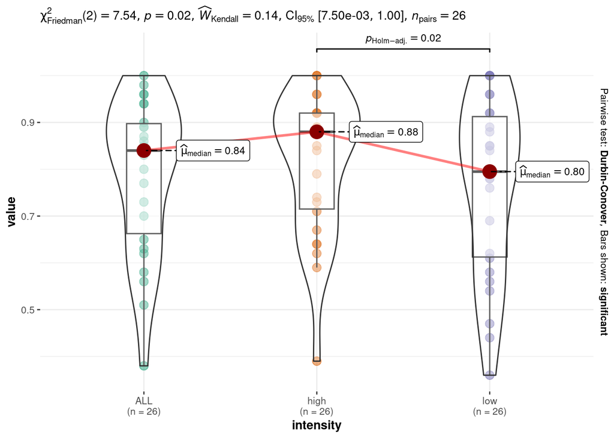

```r
df_congruence %>%
  pivot_longer(cols = c("ALL", "high", "low"), names_to = "intensity") %>%
  ggstatsplot::ggwithinstats(
    x = intensity,
    y = value,
    type = "nonparametric"
  )
```

```r
df_congruence %>%
  pivot_longer(cols = c("ALL", "high", "low"), names_to = "intensity", values_to = "value") %>%
  group_by(intensity) %>%
  summarise(
    mean = round(mean(value, na.rm = T),2),
    median = round(median(value, na.rm = T),2),
    sd = round(sd(value, na.rm = T),2)
  )
```

```
## # A tibble: 3 × 4
##   intensity  mean median    sd
##   <chr>     <dbl>  <dbl> <dbl>
## 1 ALL        0.79   0.84  0.16
## 2 high       0.81   0.88  0.15
## 3 low        0.76   0.8   0.19
```

# Now examine the same but for the validation data by Rune

Here is like having ONE subject

```r
rune_df <- read_csv(paste0(bd,"/RUNE_validation/","allEMO_validation_CLEAN.csv"))



rune_df %>%
    select(video, emotion, starts_with("r_")) %>%
    pivot_longer(starts_with("r_"), names_to = "rating") %>%
    group_by(video, emotion) %>%
    filter(value == max(value)) %>%
    filter(value != 0) %>%
    mutate(rating = str_remove(rating,"r_")) %>%
    mutate(consistent = ifelse(emotion==rating,1,0)) %>%
    ungroup %>%
    # group_by(emotion) %>%  # uncomment here to have the congruence by emotion
    summarise(
      congruence = round(sum(consistent)/n(),2)
    )
```

```
## # A tibble: 1 × 1
##   congruence
##        <dbl>
## 1       0.82
```

# Calculate deviations of each subject from the validation data

This should be done with RSA, that is: - we take all the 56 x 6 rows of each sub, - calculate the distance matrix - get the tril - calculate the distance matrix and the tril also for the validation data - calculate 1 - R between each sub and the validation

First we need to import a few funs

```r
# ----------- DDOS - Do Distance Or Similarity -----------
# The input matrix should be observations-by-variables, that is:
# - rows index observations
# - columns index variables
# This is the format required by dist(), while for cor() is the
# opposite, so when using the cor() function we pass t(X)

library(proxy)

DDOS <- function(X, method) {

  X[is.na(X)] = 0

  switch(method,
         pearson = {
           D <- 1 - cor(t(X), method = "pearson") %>% as.dist()
         },

         spearman = {
           D <- 1 - cor(t(X), method = "spearman") %>% as.dist()
         },

         euclidean = {
           D <- dist(X, method = "euclidean")
         },

         cosine = {
           D <- 1 - simil(X, method = "cosine")
         },

         mahalanobis = {
           D <- dist(X, method = "mahalanobis")
         },
         stop("Supported methods: 'pearson', 'spearman', 'euclidean', 'cosine' or 'mahalanobis'.")
  )
  return(D)
}

# # example usage:
# DDOS(Y, method = "cosine")




# ------------------- Ratings RDM calculation --------------------

# # Function to calculate the ratings RDM for one sub
# sub_id = "02"
# dist_method_rating <- "euclidean"
# rats <- read_csv(ratings_path)
# ncomp_svd = 3

do_RDM_ratings_one_sub <- function(rats, dist_method_rating) {

  rats_one_sub <- rats %>% select(starts_with("r_"))

  D_rats <- DDOS(rats_one_sub, method = dist_method_rating)
  D_rats[is.na(D_rats)] <- 0

  D_feature_vector <- D_rats[!is.na(D_rats)]

  return(D_feature_vector)

}


test_tril <- do_RDM_ratings_one_sub(rune_df,dist_method_rating = "euclidean")
```

**VERY IMPORTANT** to make the comparison correct, we need to have the same order of movies!! Therefore use group_by(sub) and arrange(video)

```r
# first calculate the RDM_validation
# NB: we nest it so that we can have the same df structure of the RDM_subs and
# easily join them
RDM_validation <- rune_df %>%
  arrange(video) %>%
  nest %>%
  mutate(RDM_validation = map(data, ~ do_RDM_ratings_one_sub(.x, dist_method_rating = "euclidean"))) %>%
  select(RDM_validation)


# calculate the RDM_subs
RDM_subs <- df %>%
  group_by(sub) %>%
  arrange(sub,video) %>%
  nest %>%
  mutate(RDM_subs = map(data, ~ do_RDM_ratings_one_sub(.x, dist_method_rating = "euclidean"))) %>%
  select(sub, RDM_subs)


# Put them together with a cross_join and finally calculate the similarity of each sub rating
# to the reference estimated by Rune
similarity_sub_rating_reference <- cross_join(RDM_subs,RDM_validation) %>%
  mutate(
    similarity_2_reference = list(RDM_subs, RDM_validation) %>% pmap_dbl(~ cor(.x, .y, method = "pearson"))
  ) %>%
  mutate(similarity_2_reference = round(similarity_2_reference, 2)) %>%
  select(!starts_with("RDM")) %>%
  arrange(desc(similarity_2_reference))

similarity_sub_rating_reference
```

```
## # A tibble: 26 × 2
## # Groups:   sub [26]
##    sub   similarity_2_reference
##    <chr>                  <dbl>
##  1 32                      0.85
##  2 03                      0.8
##  3 31                      0.76
##  4 09                      0.75
##  5 11                      0.72
##  6 15                      0.71
##  7 26                      0.71
##  8 27                      0.71
##  9 02                      0.7
## 10 21                      0.7
## # ℹ 16 more rows
```

# Relationship between congruence and similarity to the validation set

This is interesting, since it’s not trivial the fact that the similarity of each sub to the normative rating data is proportional to the congruence. But actually it is!

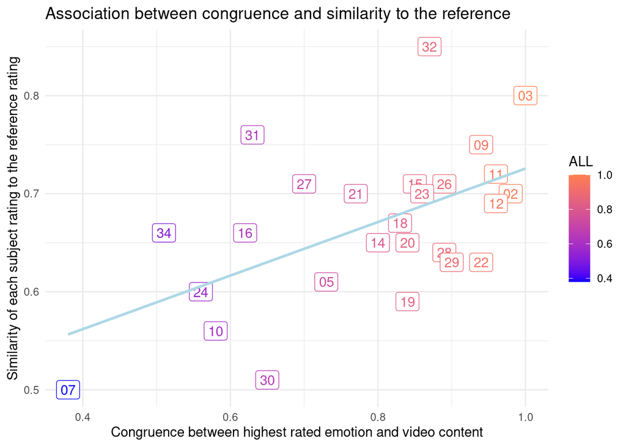

```r
congruence_and_similarity_to_reference <- inner_join(similarity_sub_rating_reference, df_congruence, by = "sub")

congruence_and_similarity_to_reference %>%
  ggplot(aes(x = ALL, y = similarity_2_reference)) +
  geom_point() +
  geom_label(aes(color = ALL, label = sub)) +
  geom_smooth(method = "lm", se = F, color = "lightblue") +
  theme_minimal() +
  labs(
    title = "Association between congruence and similarity to the reference",
    x = "Congruence between highest rated emotion and video content",
    y = "Similarity of each subject rating to the reference rating"
  ) +
  scale_color_gradient(low = "blue", high = "coral")
```

```r
fit <- lm(ALL ~ similarity_2_reference, data = congruence_and_similarity_to_reference)

jtools::summ(fit)
```

```
## MODEL INFO:
## Observations: 26
## Dependent Variable: ALL
## Type: OLS linear regression
##
## MODEL FIT:
## F(1,24) = 10.73, p = 0.00
## R² = 0.31
## Adj. R² = 0.28
##
## Standard errors: OLS
## ----------------------------------------------------------
##                                Est.   S.E.   t val.      p
## ---------------------------- ------ ------ -------- ------
## (Intercept)                    0.03   0.23     0.14   0.89
## similarity_2_reference         1.13   0.35     3.28   0.00
## ----------------------------------------------------------
```

# Plot all ratings for participants above and below a given congruence

This is a great plot because it shows the difference between people with high and low congruence:

- people with low congruence tend to give > 0 ratings to different emotions for each movie
- on average the rating for the congruent movie appears to be similar for both people above and below congruence, although in some cases it is higher for people with high congruence

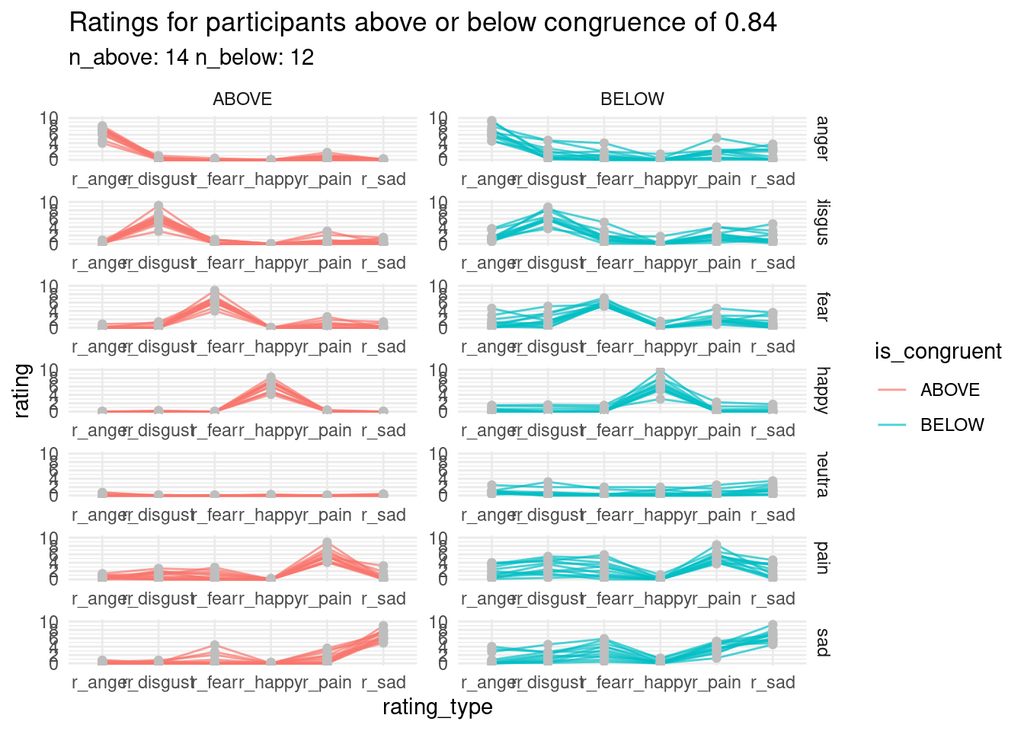

```r
congruence_threshold <- 0.84

# tmp <- df_congruence %>%
#   count(is_congruent = ALL >= congruence_threshold)

n_above <- which(df_congruence$ALL >= congruence_threshold) %>% length
n_below <- length(df_congruence$sub) - n_above

df %>%
  select(sub, starts_with("r_"), emotion) %>%
  inner_join(df_congruence %>% select(sub, ALL), by = "sub") %>%
  mutate(is_congruent = ifelse(ALL >= congruence_threshold, "ABOVE", "BELOW")) %>%
  mutate(is_congruent = factor(is_congruent)) %>%
  select(-ALL) %>%
  group_by(sub, emotion, is_congruent) %>%
  reframe(
    across(starts_with("r_"), ~ round(mean(.),2))
  ) %>%
  pivot_longer(cols = starts_with("r_"), names_to = "rating_type", values_to = "rating") %>%
  ggplot(aes(x = rating_type, y = rating, color = is_congruent, group = sub)) +
  geom_line(linewidth = 0.5, alpha = 0.7) +
  geom_point(color = "grey") +
  scale_y_continuous(limits = c(0, 10), breaks = seq(0, 10, by = 2)) +  # Setting y-axis limits and breaks
  facet_grid(emotion ~ is_congruent, axes = "all", axis.labels = "all") +
  theme_minimal() +
  labs(
    title = paste0("Ratings for participants above or below congruence of ", congruence_threshold),
    subtitle = paste0("n_above: ", n_above, " n_below: ", n_below)
  )
```